# Effect of the School Learning Environment on Students’ Outcomes: Comparing Modern and Traditional Teaching Styles

This notebook examines the relationship between teacher quality, learning environment and academic achievements/wellness of students. Specifically, this analysis compares the mediation effects of teacher quality/learning space on students’ outcomes through their attitudes towards math by teaching styles (modern and traditional). Methodologically, this notebook represents the results of the multigroup Structural Equations Modelling (SEM).

A set of variables under consideration:

- **Teaching Styles**: TRADITIONAL (Teaches use layouts that support explicit instruction/ presentation *everyday* AND *never* need to rearrange tables, chairs or other aspects of the space (e.g. sliding partitions) prior to the start of a lesson because a previous user had them in a different position) vs. MODERN (the rest)
- **Math and Science Achievements**, constructed as factor scores from five plausible values (TIMSS).
- **Wellness** - factor scores from items on students’ evaluation of their school (Q13 TIMSS).
- **Students Beliefs and Attitudes** - a higher order reflective factor composed of 3 factors representing if students enjoy math, if they think math is important, and if they are good at math (Q16, Q19, Q20 TIMSS).
- **Teacher Quality** - a formative construct, which included 2 reflective factors depicting if a teacher is understandable and if classes are well-organised (Q17, Q18 TIMSS).
- **Spatial Measures (SUS)**:
  - Technology - a number of learning tasks for which technology devices were used in a typical week.
  - Safety - a factor on manifest variables about feeling at ease in school.
  - Comfort Furniture - a factor on items about comfortability of desks/tables and chairs in the rooms students use.
  - Class Conditions - a higher order reflective construct composed of 3 factors: audibility (students hear everything clearly in the rooms where they have lessons), visibility (students clearly see everything that is shown in different rooms), temperature (temperature in the rooms is comfortable).

### Exploratory View

```r
library(ggpubr)
# Math
p1 <- stu_sus_timss %>%
  ggplot(aes(x = math_scores, fill = factor(traditional_style,
                                            labels = c('Modern Teaching Style',
                                                       'Traditional Teaching Style'))))  +
  geom_density(alpha = .3) +
  theme_classic() +
  scale_fill_manual(values = c('deepskyblue2', 'darksalmon')) +
  labs(x = "Scores", y = "Density", fill = "") +
  geom_vline(aes(xintercept = mean(stu_sus_timss[traditional_style == 1, 'math_scores'])),
             color = "darksalmon", linetype = "dashed", size = 1.5) +
  geom_vline(aes(xintercept = mean(stu_sus_timss[traditional_style == 0, 'math_scores'])),
             color = "deepskyblue2", linetype = "dashed", size = 1.5) +
  theme(plot.title = element_text(size = 15, face = "bold", hjust = 0.5),
        legend.position = "bottom") +
  ggplot2::annotate("text", label = paste0(as.character(round(mean(stu_sus_timss[stu_sus_timss$traditional_style == 1, 'math_scores']), 1)),
                                           "\nMean Score"), x = 400, y = 0.003, size = 4,
                    colour = "darksalmon") +
  ggplot2::annotate("text", label = paste0(as.character(round(mean(stu_sus_timss[stu_sus_timss$traditional_style == 0, 'math_scores']), 1)),
                                           "\nMean Score"), x = 700, y = 0.003, size = 4,
                    colour = "deepskyblue2") +
  theme(legend.text = element_text(size = 14),
        axis.text = element_text(size = 12),
        axis.title = element_text(size = 14),
        plot.subtitle = element_text(colour = "red"))+
   labs(subtitle = 'Math**')
# Science
p2 <- stu_sus_timss %>%
  ggplot(aes(x = science_scores, fill = factor(traditional_style,
                                            labels = c('Modern Teaching Style',
                                                       'Traditional Teaching Style'))))  +
  geom_density(alpha = .3) +
  theme_classic() +
  scale_fill_manual(values = c('deepskyblue2', 'darksalmon')) +
  labs(x = "Scores", y = "Density", fill = "") +
  geom_vline(aes(xintercept = mean(stu_sus_timss[traditional_style == 1, 'science_scores'])),
             color = "darksalmon", linetype = "dashed", size = 1.5) +
  geom_vline(aes(xintercept = mean(stu_sus_timss[traditional_style == 0, 'science_scores'])),
             color = "deepskyblue2", linetype = "dashed", size = 1.5) +
  theme(plot.title = element_text(size = 15, face = "bold", hjust = 0.5),
        legend.position = "bottom") +
  ggplot2::annotate("text", label = paste0(as.character(round(mean(stu_sus_timss[stu_sus_timss$traditional_style == 1, 'science_scores']), 1)),
                                           "\nMean Score"), x = 400, y = 0.003, size = 4,
                    colour = "darksalmon") +
  ggplot2::annotate("text", label = paste0(as.character(round(mean(stu_sus_timss[stu_sus_timss$traditional_style == 0, 'science_scores']), 1)),
                                           "\nMean Score"), x = 700, y = 0.003, size = 4,
                    colour = "deepskyblue2") +
  theme(legend.text = element_text(size = 14),
        axis.text = element_text(size = 12),
        axis.title = element_text(size = 14),
        plot.subtitle = element_text(colour = "red")) +
   labs(subtitle = 'Science')
# Wellness
p3 <- stu_sus_timss %>%
  ggplot(aes(x = wellness, fill = factor(traditional_style,
                                            labels = c('Modern Teaching Style',
                                                       'Traditional Teaching Style'))))  +
  geom_density(alpha = .3) +
  theme_classic() +
  scale_fill_manual(values = c('deepskyblue2', 'darksalmon')) +
  labs(x = "Scores", y = "Density", fill = "") +
  geom_vline(aes(xintercept = mean(stu_sus_timss[traditional_style == 1, 'wellness'])),
             color = "darksalmon", linetype = "dashed", size = 1.5) +
  geom_vline(aes(xintercept = mean(stu_sus_timss[traditional_style == 0, 'wellness'])),
             color = "deepskyblue2", linetype = "dashed", size = 1.5) +
  theme(plot.title = element_text(size = 15, face = "bold", hjust = 0.5),
        legend.position = "bottom") +
  ggplot2::annotate("text", label = paste0(as.character(round(mean(stu_sus_timss[stu_sus_timss$traditional_style == 1, 'wellness']), 1)),
                                           "\nMean Score"), x = 2, y = 0.3, size = 4,
                    colour = "darksalmon") +
  ggplot2::annotate("text", label = paste0(as.character(round(mean(stu_sus_timss[stu_sus_timss$traditional_style == 0, 'wellness']), 1)),
                                           "\nMean Score"), x = 4, y = 0.3, size = 4,
                    colour = "deepskyblue2") +
  theme(legend.text = element_text(size = 14),
        axis.text = element_text(size = 12),
        axis.title = element_text(size = 14),
        plot.subtitle = element_text(colour = "red")) +
   labs(subtitle = 'Wellness')
# Math Reasoning
p4 <- stu_sus_timss %>%
  ggplot(aes(x = math_reason_scores, fill = factor(traditional_style,
                                            labels = c('Modern Teaching Style',
                                                       'Traditional Teaching Style'))))  +
  geom_density(alpha = .3) +
  theme_classic() +
  scale_fill_manual(values = c('deepskyblue2', 'darksalmon')) +
  labs(x = "Scores", y = "Density", fill = "") +
  geom_vline(aes(xintercept = mean(stu_sus_timss[traditional_style == 1, 'math_reason_scores'])),
             color = "darksalmon", linetype = "dashed", size = 1.5) +
  geom_vline(aes(xintercept = mean(stu_sus_timss[traditional_style == 0, 'math_reason_scores'])),
             color = "deepskyblue2", linetype = "dashed", size = 1.5) +
  theme(plot.title = element_text(size = 15, face = "bold", hjust = 0.5),
        legend.position = "bottom") +
  ggplot2::annotate("text", label = paste0(as.character(round(mean(stu_sus_timss[stu_sus_timss$traditional_style == 1, 'math_reason_scores']), 1)),
                                           "\nMean Score"), x = 400, y = 0.003, size = 4,
                    colour = "darksalmon") +
  ggplot2::annotate("text", label = paste0(as.character(round(mean(stu_sus_timss[stu_sus_timss$traditional_style == 0, 'math_reason_scores']), 1)),
                                           "\nMean Score"), x = 700, y = 0.003, size = 4,
                    colour = "deepskyblue2") +
  theme(legend.text = element_text(size = 14),
        axis.text = element_text(size = 12),
        axis.title = element_text(size = 14),
        plot.subtitle = element_text(colour = "red")) +
   labs(subtitle = 'Math Reasoning**')
# Science Reasoning
p5 <- stu_sus_timss %>%
  ggplot(aes(x = science_reason_scores, fill = factor(traditional_style,
                                            labels = c('Modern Teaching Style',
                                                       'Traditional Teaching Style'))))  +
  geom_density(alpha = .3) +
  theme_classic() +
  scale_fill_manual(values = c('deepskyblue2', 'darksalmon')) +
  labs(x = "Scores", y = "Density", fill = "") +
  geom_vline(aes(xintercept = mean(stu_sus_timss[traditional_style == 1, 'science_reason_scores'])),
             color = "darksalmon", linetype = "dashed", size = 1.5) +
  geom_vline(aes(xintercept = mean(stu_sus_timss[traditional_style == 0, 'science_reason_scores'])),
             color = "deepskyblue2", linetype = "dashed", size = 1.5) +
  theme(plot.title = element_text(size = 15, face = "bold", hjust = 0.5),
        legend.position = "bottom") +
  ggplot2::annotate("text", label = paste0(as.character(round(mean(stu_sus_timss[stu_sus_timss$traditional_style == 1, 'science_reason_scores']), 1)),
                                           "\nMean Score"), x = 400, y = 0.003, size = 4,
                    colour = "darksalmon") +
  ggplot2::annotate("text", label = paste0(as.character(round(mean(stu_sus_timss[stu_sus_timss$traditional_style == 0, 'science_reason_scores']), 1)),
                                           "\nMean Score"), x = 700, y = 0.003, size = 4,
                    colour = "deepskyblue2") +
  theme(legend.text = element_text(size = 14),
        axis.text = element_text(size = 12),
        axis.title = element_text(size = 14),
        plot.subtitle = element_text(colour = "red")) +
   labs(subtitle = 'Science Reasoning')
# Math Applying
p6 <- stu_sus_timss %>%
  ggplot(aes(x = math_appl_scores, fill = factor(traditional_style,
                                            labels = c('Modern Teaching Style',
                                                       'Traditional Teaching Style'))))  +
  geom_density(alpha = .3) +
  theme_classic() +
  scale_fill_manual(values = c('deepskyblue2', 'darksalmon')) +
  labs(x = "Scores", y = "Density", fill = "") +
  geom_vline(aes(xintercept = mean(stu_sus_timss[traditional_style == 1, 'math_appl_scores'])),
             color = "darksalmon", linetype = "dashed", size = 1.5) +
  geom_vline(aes(xintercept = mean(stu_sus_timss[traditional_style == 0, 'math_appl_scores'])),
             color = "deepskyblue2", linetype = "dashed", size = 1.5) +
  theme(plot.title = element_text(size = 15, face = "bold", hjust = 0.5),
        legend.position = "bottom") +
  ggplot2::annotate("text", label = paste0(as.character(round(mean(stu_sus_timss[stu_sus_timss$traditional_style == 1, 'math_appl_scores']), 1)),
                                           "\nMean Score"), x = 400, y = 0.003, size = 4,
                    colour = "darksalmon") +
  ggplot2::annotate("text", label = paste0(as.character(round(mean(stu_sus_timss[stu_sus_timss$traditional_style == 0, 'math_appl_scores']), 1)),
                                           "\nMean Score"), x = 700, y = 0.003, size = 4,
                    colour = "deepskyblue2") +
  theme(legend.text = element_text(size = 14),
        axis.text = element_text(size = 12),
        axis.title = element_text(size = 14),
        plot.subtitle = element_text(colour = "red")) +
   labs(subtitle = 'Math Applying**')
# Science Applying
p7 <- stu_sus_timss %>%
  ggplot(aes(x = science_appl_scores, fill = factor(traditional_style,
                                            labels = c('Modern Teaching Style',
                                                       'Traditional Teaching Style'))))  +
  geom_density(alpha = .3) +
  theme_classic() +
  scale_fill_manual(values = c('deepskyblue2', 'darksalmon')) +
  labs(x = "Scores", y = "Density", fill = "") +
  geom_vline(aes(xintercept = mean(stu_sus_timss[traditional_style == 1, 'science_appl_scores'])),
             color = "darksalmon", linetype = "dashed", size = 1.5) +
  geom_vline(aes(xintercept = mean(stu_sus_timss[traditional_style == 0, 'science_appl_scores'])),
             color = "deepskyblue2", linetype = "dashed", size = 1.5) +
  theme(plot.title = element_text(size = 15, face = "bold", hjust = 0.5),
        legend.position = "bottom") +
  ggplot2::annotate("text", label = paste0(as.character(round(mean(stu_sus_timss[stu_sus_timss$traditional_style == 1, 'science_appl_scores']), 1)),
                                           "\nMean Score"), x = 400, y = 0.003, size = 4,
                    colour = "darksalmon") +
  ggplot2::annotate("text", label = paste0(as.character(round(mean(stu_sus_timss[stu_sus_timss$traditional_style == 0, 'science_appl_scores']), 1)),
                                           "\nMean Score"), x = 700, y = 0.003, size = 4,
                    colour = "deepskyblue2") +
  theme(legend.text = element_text(size = 14),
        axis.text = element_text(size = 12),
        axis.title = element_text(size = 14),
        plot.subtitle = element_text(colour = "red")) +
   labs(subtitle = 'Science Applying')
# Math Knowing
p8 <- stu_sus_timss %>%
  ggplot(aes(x = math_know_scores, fill = factor(traditional_style,
                                            labels = c('Modern Teaching Style',
                                                       'Traditional Teaching Style'))))  +
```

```r
  geom_density(alpha = .3) +
  theme_classic() +
  scale_fill_manual(values = c('deepskyblue2', 'darksalmon')) +
  labs(x = "Scores", y = "Density", fill = "") +
  geom_vline(aes(xintercept = mean(stu_sus_timss[traditional_style == 1, 'math_know_scores'])),
             color = "darksalmon", linetype = "dashed", size = 1.5) +
  geom_vline(aes(xintercept = mean(stu_sus_timss[traditional_style == 0, 'math_know_scores'])),
             color = "deepskyblue2", linetype = "dashed", size = 1.5) +
  theme(plot.title = element_text(size = 15, face = "bold", hjust = 0.5),
        legend.position = "bottom") +
  ggplot2::annotate("text", label = paste0(as.character(round(mean(stu_sus_timss[stu_sus_timss$traditional_style == 1, 'math_know_scores']), 1)),
                                           "\nMean Score"), x = 400, y = 0.003, size = 4,
                    colour = "darksalmon") +
  ggplot2::annotate("text", label = paste0(as.character(round(mean(stu_sus_timss[stu_sus_timss$traditional_style == 0, 'math_know_scores']), 1)),
                                           "\nMean Score"), x = 700, y = 0.003, size = 4,
                    colour = "deepskyblue2") +
  theme(legend.text = element_text(size = 14),
        axis.text = element_text(size = 12),
        axis.title = element_text(size = 14),
        plot.subtitle = element_text(colour = "red")) +
   labs(subtitle = 'Math Knowing*')
# Science Knowing
p9 <- stu_sus_timss %>%
  ggplot(aes(x = science_know_scores, fill = factor(traditional_style,
                                            labels = c('Modern Teaching Style',
                                                       'Traditional Teaching Style'))))  +
  geom_density(alpha = .3) +
  theme_classic() +
  scale_fill_manual(values = c('deepskyblue2', 'darksalmon')) +
  labs(x = "Scores", y = "Density", fill = "") +
  geom_vline(aes(xintercept = mean(stu_sus_timss[traditional_style == 1, 'science_know_scores'])),
             color = "darksalmon", linetype = "dashed", size = 1.5) +
  geom_vline(aes(xintercept = mean(stu_sus_timss[traditional_style == 0, 'science_know_scores'])),
             color = "deepskyblue2", linetype = "dashed", size = 1.5) +
  theme(plot.title = element_text(size = 15, face = "bold", hjust = 0.5),
        legend.position = "bottom") +
  ggplot2::annotate("text", label = paste0(as.character(round(mean(stu_sus_timss[stu_sus_timss$traditional_style == 1, 'science_know_scores']), 1)),
                                           "\nMean Score"), x = 400, y = 0.003, size = 4,
                    colour = "darksalmon") +
  ggplot2::annotate("text", label = paste0(as.character(round(mean(stu_sus_timss[stu_sus_timss$traditional_style == 0, 'science_know_scores']), 1)),
                                           "\nMean Score"), x = 700, y = 0.003, size = 4,
                    colour = "deepskyblue2") +
  theme(legend.text = element_text(size = 14),
        axis.text = element_text(size = 12),
        axis.title = element_text(size = 14),
        plot.subtitle = element_text(colour = "red")) +
   labs(subtitle = 'Science Knowing')
p12 <- ggarrange(p1, p2, ncol = 1, nrow = 2, common.legend = T, legend = 'bottom')
p45 <- ggarrange(p4, p5, ncol = 1, nrow = 2, common.legend = T, legend = 'bottom')
p67 <- ggarrange(p6, p7, ncol = 1, nrow = 2, common.legend = T, legend = 'bottom')
p89 <- ggarrange(p8, p9, ncol = 1, nrow = 2, common.legend = T, legend = 'bottom')
```

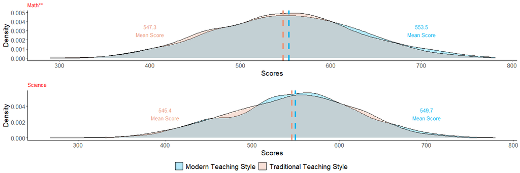

```r
p12
```

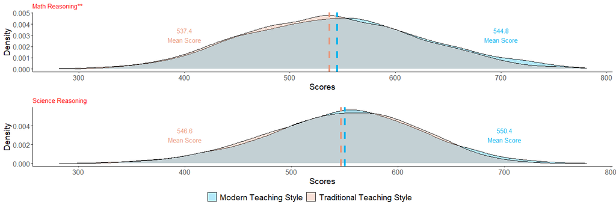

```r
p45
```

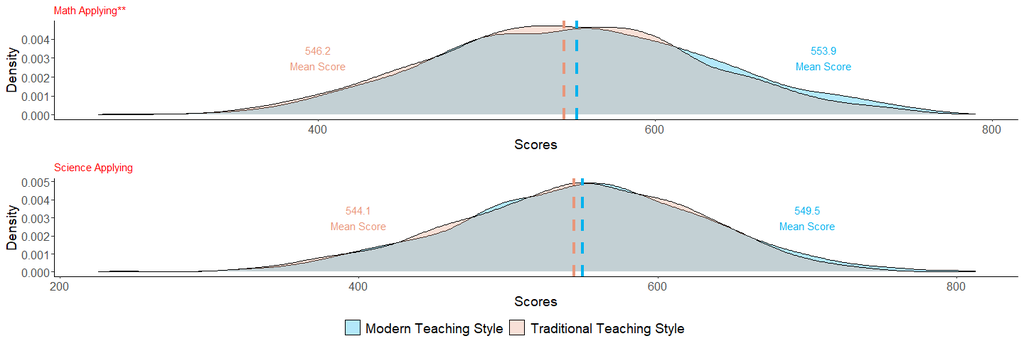

```r
p67
```

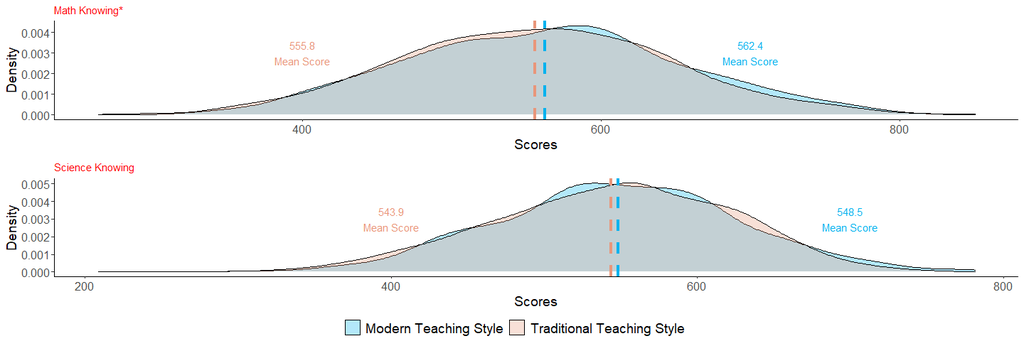

```r
p89
```

```r
# t.tests
# Math
wtd.t.test(stu_sus_timss$math_scores[stu_sus_timss$traditional_style == 1],
           stu_sus_timss$math_scores[stu_sus_timss$traditional_style == 0],
           stu_sus_timss$TOTWGT[stu_sus_timss$traditional_style == 1],
           stu_sus_timss$TOTWGT[stu_sus_timss$traditional_style == 0],
           samedata = F)
```

```
$test
[1] "Two Sample Weighted T-Test (Welch)"

$coefficients
      t.value            df       p.value
  -1.81635090 1759.27374290    0.06948668

$additional
Difference     Mean.x     Mean.y   Std. Err
 -5.819471 546.130396 551.949867   3.203935
```

```r
# Math Reasoning
wtd.t.test(stu_sus_timss$math_reason_scores[stu_sus_timss$traditional_style == 1],
           stu_sus_timss$math_reason_scores[stu_sus_timss$traditional_style == 0],
           stu_sus_timss$TOTWGT[stu_sus_timss$traditional_style == 1],
           stu_sus_timss$TOTWGT[stu_sus_timss$traditional_style == 0],
           samedata = F)
```

```
$test
[1] "Two Sample Weighted T-Test (Welch)"

$coefficients
      t.value            df       p.value
  -2.20720238 1769.45736770    0.02742787

$additional
Difference     Mean.x     Mean.y   Std. Err
 -7.311333 536.331855 543.643187   3.312488
```

```r
# Math Applying
wtd.t.test(stu_sus_timss$math_appl_scores[stu_sus_timss$traditional_style == 1],
           stu_sus_timss$math_appl_scores[stu_sus_timss$traditional_style == 0],
           stu_sus_timss$TOTWGT[stu_sus_timss$traditional_style == 1],
           stu_sus_timss$TOTWGT[stu_sus_timss$traditional_style == 0],
           samedata = F)
```

```
$test
[1] "Two Sample Weighted T-Test (Welch)"

$coefficients
      t.value            df       p.value
  -2.34200622 1756.09255646    0.01929161

$additional
Difference     Mean.x     Mean.y   Std. Err
 -7.546480 544.947478 552.493958   3.222229
```

```r
# Math Knowing
wtd.t.test(stu_sus_timss$math_know_scores[stu_sus_timss$traditional_style == 1],
           stu_sus_timss$math_know_scores[stu_sus_timss$traditional_style == 0],
           stu_sus_timss$TOTWGT[stu_sus_timss$traditional_style == 1],
           stu_sus_timss$TOTWGT[stu_sus_timss$traditional_style == 0],
           samedata = F)
```

```
$test
[1] "Two Sample Weighted T-Test (Welch)"

$coefficients
      t.value            df       p.value
  -1.90968919 1792.64037788    0.05633271

$additional
Difference     Mean.x     Mean.y   Std. Err
 -6.824159 554.240398 561.064558   3.573440
```

Further, we compare the mediated effects of Teacher Quality/Space on Achievements/Wellness BY teaching styles.

### Analysis

We created factor models for each students’ outcomes separately and established the models’ measurement invariance to proceed with comparison. In all models, goodness-of-fit criteria indicated models of high quality. The models assume the existence of only indirect effects; therefore, all direct relationships were set to zero on theoretical grounds (e.g., teacher quality cannot influence learning outcomes without influencing students themselves, i.e. their attitudes & beliefs).

Green links depict positive effects, grey links – the insignificant ones. The connections from the lower-order factors to the respective items are not shown (for readability purposes). Technology is the only observed measurement in the models. To calculate an indirect effect of a predictor to an outcome through a mediator, it is sufficient to multiply 2 coefficients – the effect of a predictor on a mediator and of a mediator on an outcome.

To determine which structural paths vary between modern and traditional styles and which do not, we implemented a multigroup SEM procedure by iteratively constraining to equality the effects of interest and comparing the constrained and free models.

The main findings:

- **Teacher Quality** positively affects all outcomes through improving students’ attitudes towards math. This effect does not differ between teaching styles.
- **Technology** (a number of learning tasks for which technology devices were used in a typical week) positively affects all outcomes through improving students’ attitudes towards math. This effect is stronger for the modern style with regard to math, science, and (Math) applying.
- **Comfort furniture** positively affects math, science, and (Math) applying through improving students’ attitudes towards math only for the modern style; for the traditional style the association is not significant.
- The rest of the effects are not statistically significant.

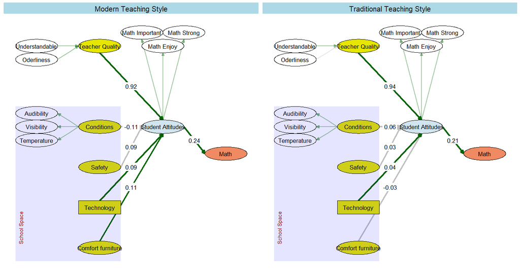

```r
plot_multi_all[[1]]
```

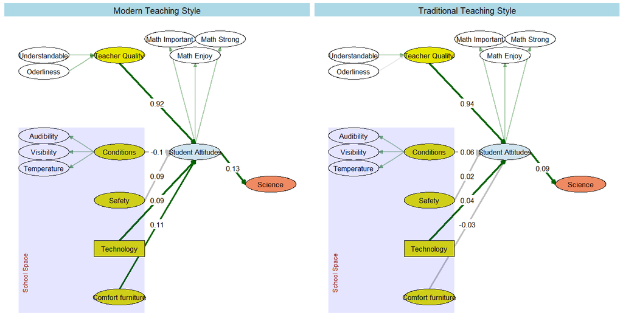

```r
plot_multi_all[[2]]
```

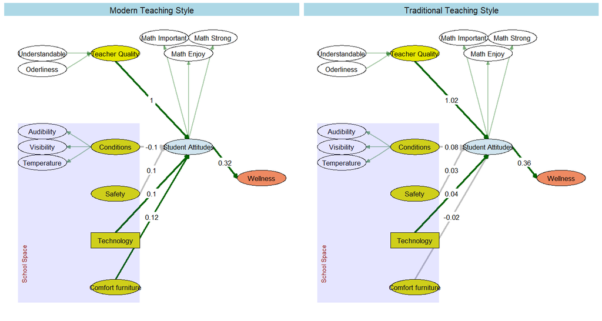

```r
plot_multi_all[[3]]
```

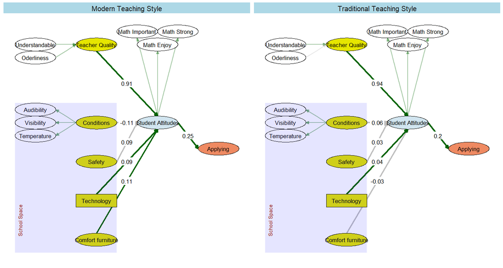

```r
plot_multi_all[[4]]
```

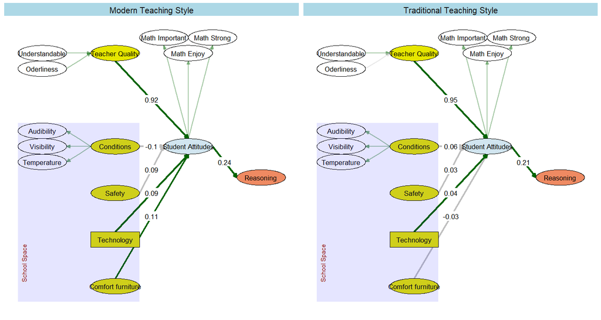

```r
plot_multi_all[[5]]
```

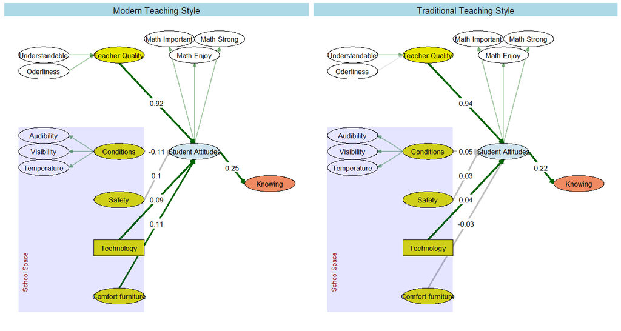

```r
plot_multi_all[[6]]
```